# Assignment IV

Jeremy Gachanja

8/7/2022

# a) Clearly distinguish the following terms

## i. Stochastic Process and Deterministic Data

## ii. Discrete and Continuous stochastic process.

## iii. algebra and Filtration

## iv. Random Walk and Gambler’s Ruin Problem

## v. Counting Process and Branching Process

## vi. Birth and Death Process

## vii. Static Simulation Model and Dynamic Simulation Model

## viii. Mathematical Model and Simulation Model

## ix. Monte Carlo Simulation and Queuing System

## x. Markov and Poisson processes

## xi. Queuing and Renewal processes

## xii. Martingale and Brownian motion

## xiii. Hidden Markov model and semi-Markov process

# b) Collins bought a share of stock for $12, and it is believed that the stock price moves (day by day) as a simple random walk with p = 0.58. What is the probability that Collins’ stock reaches the high value of $35 before the low value of $8?

## solution

where a is the up movement and b is the down movement

```r
origin = 12
p = 0.58
q = 1-p
up = 35
down = 8
a = up-origin
b = origin-down
p_35 = (1-(q/p)^b)/(1-(q/p)^(a+b))
print(p_35)
```

```
## [1] 0.7251491
```

# c) Explain clearly the difference between the following terms as used in Markov Chains

## i. Communicating class and absorption state

An absorption state i is one which is impossible to leave.

Points i and j in a markov chain are said to communicate if i is reachable to j and j is rachable to i. This makes the markov chain irreducible and thus a communicating class.

## ii. Recurrence and nonrecurrence state

A recurrent state i is recurrent if and only if one starts at state i and there is a probability of 1 that one will eventually return to state i.

A non recurrent or transient state is one where if one starts at a state i the probability of returning to that state i is less than 1

## iii. Periodicity and aperiodic

A state i is periodic if one starts at state i and the number of steps to get back to that step i is greater than one.

A state i is aperiodic if one starts at state i and the number of steps to get back to that step i is equal to one.

## iv. Ergodic chain and transient state

An egordic chain is one that satisfies three conditions that is the chain is aperiodic, recurrent and irreducible.

A transient state is one where if one starts at a state i the probability of returning to that state i is less than 1.

## v. Reducible and irreducible

An irreducible chain is one where it is possible to move from any state to any other state regardless of if the path is direct or indirect.

An irreducible chain is one where it is not possible to move from any state to any other state.

# e) Clearly specify five components of a Hidden Markov Model

# f) Use Chapman Kolmogorov postulates to derive the Poisson Process. Also derive the mean and variance of the Poisson process.

# g) A certain stock price has been observed to follow a pattern. If the stock price goes up one day, there’s a 25% chance of it rising tomorrow, a 35% chance of it falling, and a 40% chance of it remaining the same. If the stock price falls one day, there’s a 25% chance of it rising tomorrow, a 50% chance of it falling, and a 25% chance of it remaining the same. Finally, if the price is stable on one day, then it has a 50-50 change of rising or falling the next day.

## i. Generate the transition matrix

### solution

```r
library(markovchain)
transition_mat=matrix(nrow = 3,ncol=3,c(0.25,0.25,0.5,0.35,0.5,0.5,0.4,0.25,0))
statesNames <- c("Up", "Down", "Stable")
markovB <- new("markovchain", states = statesNames, transitionMatrix =transition_mat, name = "A markovchain Object")
print(markovB)
```

```
##          Up Down Stable
## Up     0.25 0.35   0.40
## Down   0.25 0.50   0.25
## Stable 0.50 0.50   0.00
```

## ii. Draw the Markov chain using R

### solution

```r
library(diagram)
```

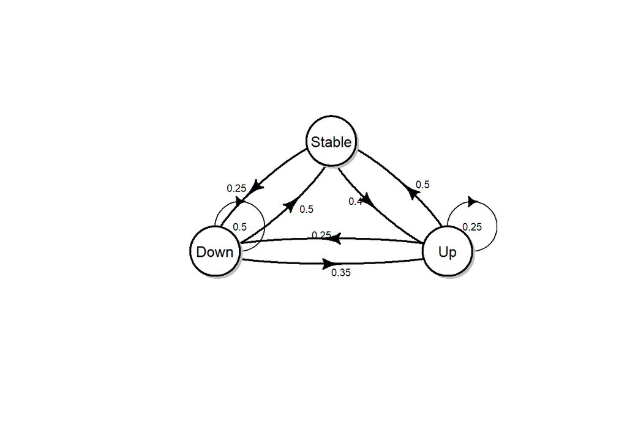

```r
rownames(transition_mat) = statesNames
colnames(transition_mat) = statesNames
plotmat(transition_mat,relsize = .65,cex=0.7)
```

## iii. Determine if the chain is Ergodic

### solution

The chain is ergodic since it is recurrent, aperiodic and irreducible.

## iv. Find the limiting distribution of the transition matrix

### solution

```r
steadyStates(markovB)
```

```
##             Up      Down    Stable
## [1,] 0.3092784 0.4536082 0.2371134
```

# h) A telephone attendant receives 110 calls during the busy hour. Each call takes, on average, 2.1 minutes to process.

## a) What percentage of the attendant’s time is devoted to answering calls?

## b) How long must people wait, on average, before their call is processed?